# NRES 315: People, Habitats, and Species

Fall 2026  
Week 01

Human Dimensions of Fish and Wildlife Management

2026-08-24

## Today’s question

When biological evidence is sound, what still has to be worked out before a fish or wildlife decision can succeed?

Source: Chapter 1, guiding questions; §§1.2–1.5.

## What you should be able to do

By the end of today, you should be able to:

- explain why management is value-laden;
- use human dimensions as a problem orientation, not merely a set of public-opinion tools;
- distinguish research, participation, and transdisciplinary collaboration; and
- identify the human work embedded in a conservation decision.

Source: Chapter 1, guiding questions and §§1.2–1.5.

## Chesapeake Bay is a shared social–ecological system

The Bay is degraded by overfishing, pollution, nutrient loading, and habitat destruction.

- Runoff from agricultural and urban areas contributes to seasonal low-oxygen “dead zones.”
- Underwater grass beds and oyster reefs have declined, reducing nursery habitat for fishery species.
- Restoration decisions affect fisheries, livelihoods, recreation, and a place with deep cultural and Indigenous significance.

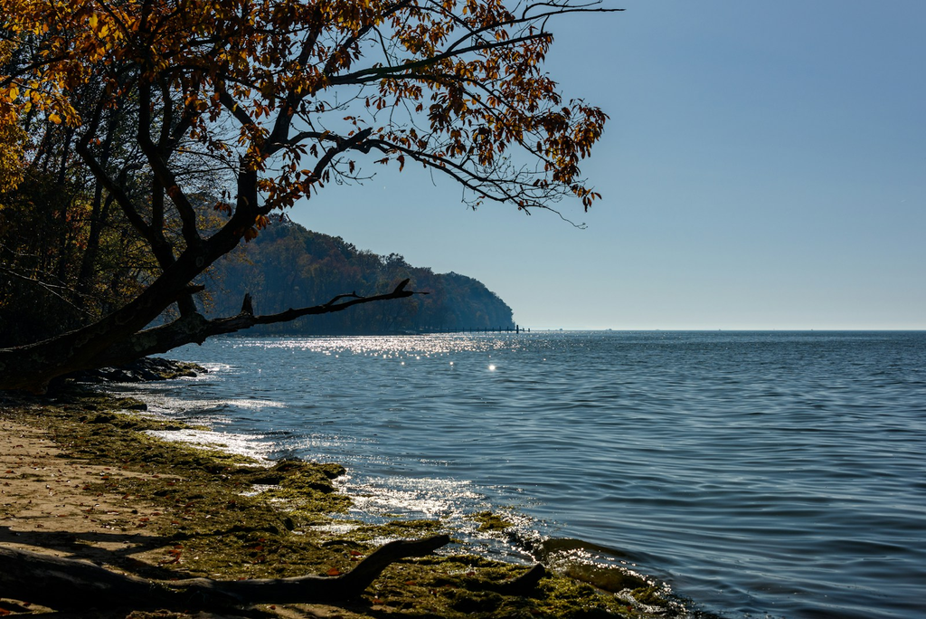

Instructional content: Chapter 1, §1.2. Illustrative image: [Steve Adams / Unsplash](https://unsplash.com/photos/brown-tree-near-body-of-water-during-daytime-ckzTyM9SbMs).

## The same Bay contains different stakes

Different publics may agree that the Bay matters while disagreeing about the problem, its causes, and acceptable solutions.

- Commercial fishers may focus on livelihood effects.
- Recreational anglers may emphasize fish abundance, clean water, and access.
- Farmers and landowners may face new runoff or conservation expectations.
- Environmental organizations may seek stricter standards.

Source: Chapter 1, §1.2.

## Diagnosing the Bay is not the same as deciding what to do

Ecological science identifies the Bay’s condition and the likely effects of actions. It does not choose the action.

**Science can clarify**

- nutrient inputs, water quality, and habitat condition;
- likely effects of management actions.

**A decision must still address**

- priority outcomes;
- acceptable tradeoffs; and
- affected publics and costs.

Ecological evidence identifies choices; values shape which choice is pursued.

Source: Chapter 1, §§1.2–1.2.1.

## Management is an expression of human values and actions

Management and conservation are value-laden enterprises.

- A value is a belief that an action—or the end state it produces—is desirable.
- Values shape the outcomes people prefer for fish, wildlife, and habitats.
- Values also shape the actions and policies people support to reach those outcomes.
- Because values differ, management choices can create conflict and tradeoffs.

Source: Chapter 1, §1.2.1, “Human Values Are Fish and Wildlife Management.”

## Decisions are nested within people, habitats, and species

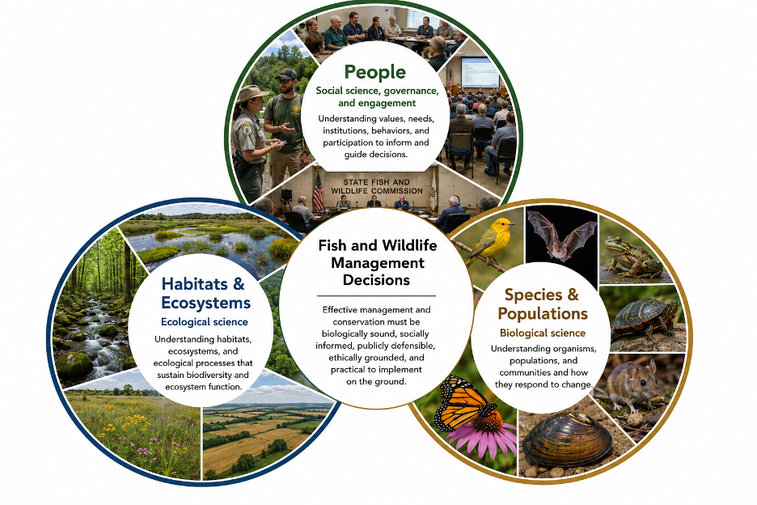

Source: Chapter 1, Figure 1.1 and §1.2.1.

## People and Natural Resources Affect Each Other

Human dimensions concerns the **human actions, social processes, and social-ecological relationships** that shape management.

- People affect fish, wildlife, and habitats through development, agriculture, harvest, recreation, and extraction.
- Fish, wildlife, and habitats affect people through subsistence, livelihoods, meanings, places, and other benefits.
- Those relationships shape management decisions.

Source: Chapter 1, §1.3.

## Human dimensions broadens the questions we ask

For a **deer season structure**, biological analysis might ask:

- How will the population change?
- What harvest level is sustainable?
- Are population goals being met?

A **human dimensions orientation** also asks:

- How will hunters respond to the season structure?
- How might it affect satisfaction, crowding, access, safety, or local economies?
- Who is affected, and what values may be in conflict?
- What evidence and public participation are needed?

Source: Chapter 1, §1.3.

## Two complementary ways of working

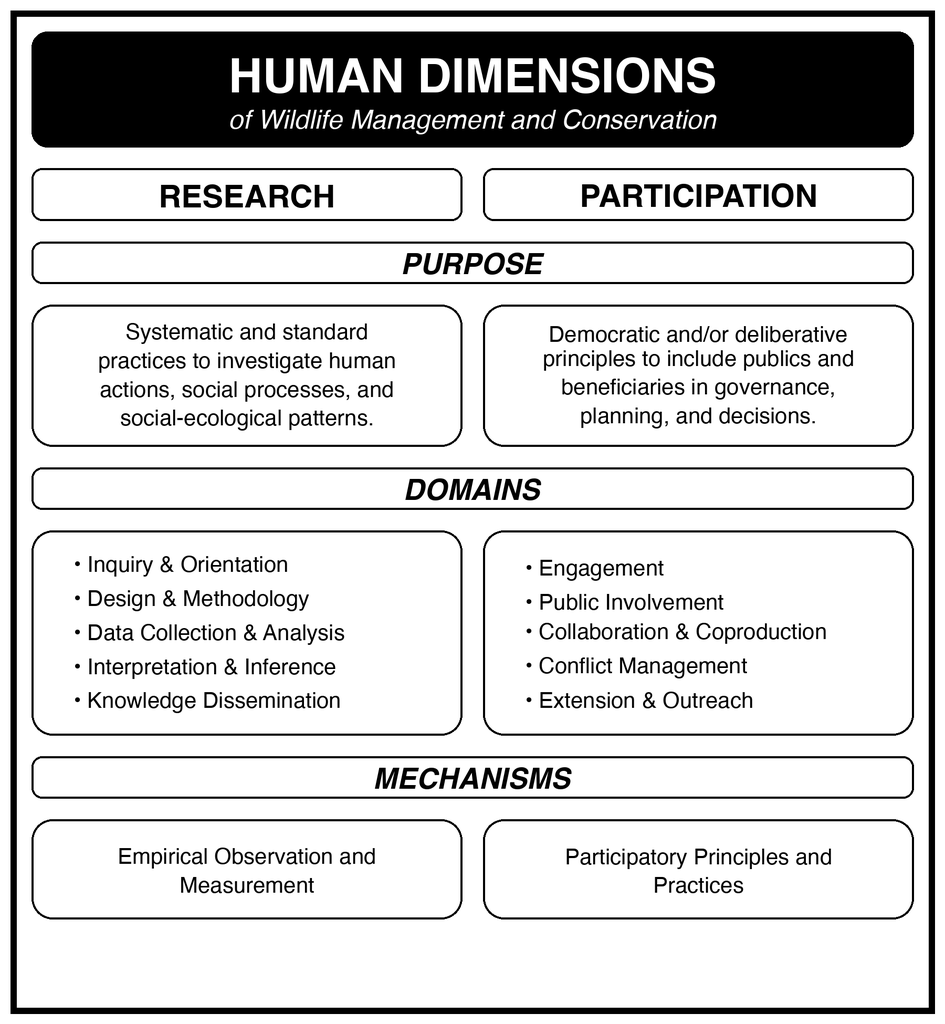

Source: Chapter 1, Figure 1.2 and §1.3.

## Research asks systematic questions about people

- The social sciences provide principles, theories, methods, standards, and criteria for rigor.
- They help professionals describe and explain human values, attitudes, behaviors, institutions, causes, and outcomes—and critically examine assumptions and biases.

“Social science” is not one expertise. Psychology, sociology, anthropology, economics, law, policy science, political ecology, and environmental humanities bring different tools.

Source: Chapter 1, §1.3.1 and Table 1.1.

## Participation has two related forms

| Public involvement | Engagement |
| --- | --- |
| Formal and legally required within a planning or decision process | Continual interaction and dialogue with publics |
| Includes notice, opportunity to participate, and a record of decision | Emphasizes shared learning, relationship-building, and trust |
| Example: notice-and-comment rulemaking | Example: an advisory group, community event, extension, or outreach |

Source: Chapter 1, §1.3.2.

## Collaboration is more than assembling experts

Transdisciplinary work goes beyond assembling academic expertise: it includes non-academic partners in defining the problem and producing useful knowledge.

[figure not shown]

Source: Chapter 1, §1.3.3.

## Collaboration requires understanding different perspectives

Working with publics means recognizing that people may understand the same problem very differently.

Their perspectives are shaped by:

- **values, beliefs, and attitudes**
- **norms and direct experiences**
- **risk perceptions and satisfaction**
- **political, historical, and cultural context**

Human dimensions helps make these differences visible and asks:

> **Will different publics experience the decision as fair, legitimate, and acceptable?**

Source: Chapter 1, §1.4.1.

## Different perspectives can create conflict—and exclusion

Human–wildlife interactions are rarely solved by **technical fixes alone**.

Lasting responses may require:

- **dialogue** among people with different interests and values;
- **trust** in agencies, processes, and other participants; and
- **meaningful participation** by affected publics.

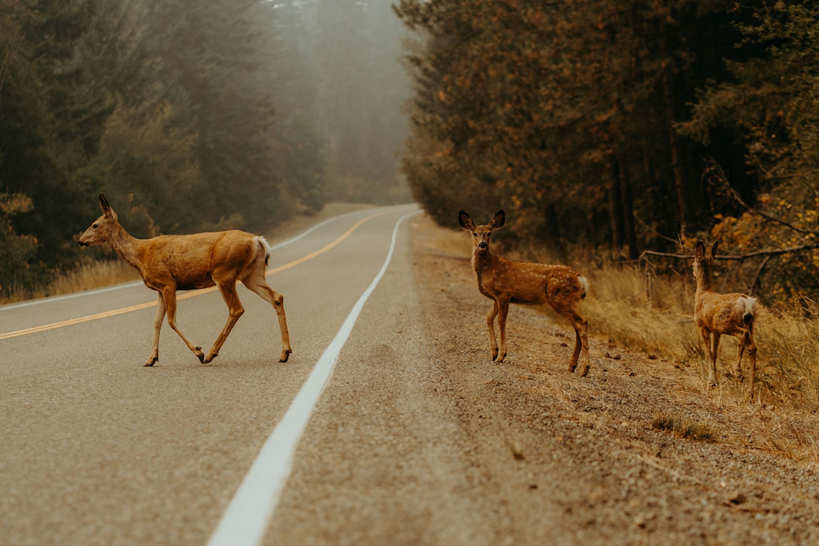

Human dimensions also asks:

> **Who gets to participate—and who bears the costs of conservation decisions?**

Instructional content: Chapter 1, §§1.4.2–1.4.3. Illustrative image: [Emmanuel Munoz / Unsplash](https://unsplash.com/photos/deer-crossing-a-road-in-a-forest-zRp7-vLJbYI).

## Management decisions happen in the real world

Natural resource professionals work within changing **social, political, economic, and environmental conditions**.

That means navigating:

- **politics and resources** — political influence, budgets, development, and competing uses;
- **trust and communication** — misinformation, public trust, and shared responsibility;
- **technology** — new opportunities for research and access, alongside ethical and equity concerns; and
- **large-scale change** — climate change and urbanization that require engagement, incentives, and collaboration.

> **Good science is necessary—but it does not determine what is feasible, acceptable, or durable.**

Source: Chapter 1, §§1.4.4–1.4.7.

## Practice: reframe Chesapeake Bay restoration

In groups, use only the Chapter 1 account of the Bay. Prepare a 60-second explanation that answers:

1. What is the ecological condition or management concern?
2. Whose values, actions, or responsibilities make this a human-dimensions problem?
3. What is one research need **and** one participation need before a durable decision?

Source: Chapter 1, §§1.2–1.3.3.

## Effective management has a wider standard

Effective management and conservation must be:

- biologically sound;
- socially informed;
- publicly defensible;
- ethically grounded; and
- practical to implement on the ground.

Source: Chapter 1, §1.5.

For Friday’s graded Chesapeake Bay application:

- make people, habitats, and species visible;
- identify two affected publics and a tradeoff; and
- distinguish evidence needed from participation needed.

The Week 1 reading quiz is due Sunday, August 30, at 11:59 p.m., before Week 02 Monday class.

Source: Chapter 1, §§1.2–1.3.3; Week 1 Canvas module.

## Exit check

Complete both statements:

1. Biological evidence cannot by itself decide ______.
2. A human-dimensions problem orientation changes a decision by asking ______.

Source: Chapter 1, §§1.2.1, 1.3, and 1.5.